# Replication Report

Hannah Hardenbergh

3/7/2019

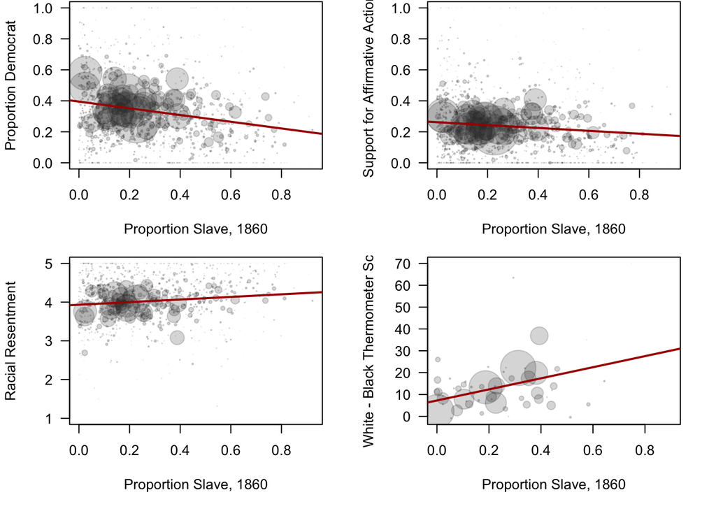

```r
#Funny, for how meticulous the readme is, they mislabeled a variable in this
#next code chunk. pslave is actually pslave1860... small error. moving on..

# par() sets parameters for graphics:

par(mfrow = c(2,2), mar = 0.1 + c(5, 4, 0, 2))

# now make the plots: Proportion Democrat

plot(south.counties$pslave1860,
     south.counties$dem,
     pch = 19,
     col = "#33333333",
     xlab = "Proportion Slave, 1860",
     ylab = "Proportion Democrat",
     yaxt = "n",

     #here I added a pipe because R wasnt recognizing the axis() call beneath
     #the plot call. I think there might be a more organized way to plot these
     #using ggplot()...

     cex = south.counties$sample.size/100) %>%
  axis(side = 2, las = 2)

abline(lm(dem ~ pslave1860,
          data = south.counties,
          weights = sample.size),
       lwd = 2,
       col = "#AA0000")

# Affirmative Action:

plot(south.counties$pslave1860,
     south.counties$affirm,
     pch = 19,
     col = "#33333333",
     xlab = "Proportion Slave, 1860",
     ylab = "Support for Affirmative Action",
     yaxt = "n",
     cex = south.counties$sample.size/100) %>%
  axis(side = 2, las = 2)

abline(lm(affirm ~ pslave1860,
          data = south.counties,
          weights = sample.size),
       lwd = 2,
       col = "#AA0000")

# Racial Resentment:

plot(south.counties$pslave1860,
     south.counties$resent,
     pch = 19,
     col = "#33333333",
     xlab = "Proportion Slave, 1860",
     ylab = "Racial Resentment",
     yaxt = "n",
     cex = south.counties$sample.size.res/75) %>%
  axis(side = 2, las = 2)

abline(lm(resent ~ pslave1860,
          data = south.counties,
          weights = sample.size.res),
       lwd = 2,
       col = "#AA0000")

# White - Black Thermometer Score:

with(subset(nes.counties,
            state.abb %in% st.list),
     plot(pslave1860,
          wtherm-btherm,
          cex = sample.size.bt/40,
          pch = 19, col = "#33333333",
          xlab = "Proportion Slave, 1860",
          ylab = "White - Black Thermometer Score",
          las = 1,
          xlim = c(0, 0.9)))

abline(lm(I(wtherm-btherm) ~ pslave1860,
          weights = sample.size.bt,
          data = subset(nes.counties, state.abb %in% st.list)),
       lwd = 2, col = "#AA0000")
```

```r
# dev.off()
```

```r
## models for Tables 1 & 2

cnty.res <- lm(dem ~ pslave1860,
               data = south.counties,
               weights = sample.size)

cnty.res.fe <- lm(dem ~ pslave1860 + state.abb,
                  data = south.counties,
                  weights = sample.size)

cnty.res.full <- lm(update(base1860.form, dem ~ .),
                    data = south.counties,
                    weights = sample.size)

cnty.aff <- lm(affirm ~ pslave1860,
               data = south.counties,
               weights = sample.size)

cnty.aff.fe <- lm(affirm ~ pslave1860 + state.abb,
                  data = south.counties,
                  weights = sample.size)

cnty.aff.full <- lm(update(base1860.form, affirm ~ .),
                    data = south.counties,
                    weights = sample.size)

cnty.resent <- lm(resent ~ pslave1860,
                  data = south.counties,
                  weights = sample.size.res)

cnty.resent.fe <- lm(resent ~ pslave1860 +  state.abb,
                     data = south.counties,
                     weights = sample.size.res)

cnty.resent.full <- lm(update(base1860.form, resent ~ .),
                       data = south.counties,
                       weights = sample.size.res)

## NES Individual Results
therm.mod <- lm(therm.diff ~ pslave1860,
                data = ns.whites,
                weights = weight)
therm.mod.rse <- robust.se(therm.mod, clvar = "fips")

therm.mod.fe <- lm(therm.diff ~ pslave1860 + state.abb*as.factor(year),
                   data = ns.whites,
                   weights = weight)
therm.mod.fe.rse <- robust.se(therm.mod.fe, clvar = "fips")

therm.1860 <- lm(update(base1860.form, therm.diff ~ . + state.abb*as.factor(year)),
                 data = ns.whites,
                 weights = weight)

therm.1860.rse <- robust.se(therm.1860, clvar = "fips")


## This code actually makes the table graphic:

tab1 <- stargazer(cnty.res,
                  cnty.res.full,
                  cnty.aff.full,
                  cnty.resent.full,
                  keep = "pslave1860",
                  style = "apsr",
                  omit.stat = c("adj.rsq","ll", "F", "ser"),
                  covariate.labels = c("Prop. Slave, 1860"),
                  dep.var.labels = c("Prop Democrat", "Affirm. Action", "Racial Resentment"),
                  column.sep.width = "0pt",
                  float = FALSE,
                  header = FALSE,
                  add.lines = list(rep("", 4),
                                   ch.row("State Fixed Effects",
                                          c(FALSE, rep(TRUE,3))),
                                   ch.row("1860 Covariates",
                                          c(FALSE, rep(TRUE,3))),
                                   rep("", 4)),
                  multicolumn = TRUE)
```

```r
# the following code creates another table like table 1 except that they add
# State-Year Fixed Effects and Clustered Standard Errors. they don't plot it and
# only use tab1. I wonder what the difference is for the final publication? why
# not include these other statistical observances?

# tab1.alt <- stargazer(cnty.res,
#                       cnty.res.full,
#                       cnty.aff.full,
#                       cnty.resent.full,
#                       therm.1860,
#                       se = list(NULL, NULL, NULL, NULL,
#                                 therm.1860.rse[,2]),
#                   keep = "pslave1860",
#                   style = "apsr",
#                   omit.stat = c("adj.rsq","ll", "F", "ser"),
#                   covariate.labels = c("Prop. Slave, 1860"),
#                   dep.var.labels = c("Prop Democrat", "Affirm. Action", "Racial Resentment"),
#                   column.sep.width = "5pt",
#                   float = FALSE,
#                   header = FALSE,
#                   add.lines = list(rep("", 4), c("Level", "County", "County", "County", "County", "Individual"),
#                                    ch.row("1860 Covariates", c(FALSE, rep(TRUE,3), FALSE)),
#                                    ch.row("State Fixed Effects", c(FALSE, rep(TRUE,4))),
#                                    ch.row("State-Year Fixed Effects", c(rep(FALSE,4), TRUE)),
#                                    ch.row("Clustered SEs", c(rep(FALSE,4), TRUE)), rep("", 4)),
#                   multicolumn = TRUE)
#
# tab1.alt[4] <- "\\\\[-1.8ex] & \\multicolumn{2}{c}{Proportion} & Support for & Racial  & White-Black  \\\\ "
#
# tab1.alt <- append(tab1.alt, " & \\multicolumn{2}{c}{Democrat} & Affirm. Action &  Resentment & Therm. Diff  \\\\ ",
#                    after = 4)
#
# tab1.alt <- gsub("\\{\\*\\}", "\\{\\\\dagger\\}", tab1.alt)
#
# tab1.alt <- gsub("\\{\\*\\*\\}", "\\{\\*\\}", tab1.alt)
#
# tab1.alt <- gsub("\\{\\*\\*\\*\\}", "\\{\\*\\*\\}", tab1.alt)
#
# tab1.alt <- tab1.alt[-(length(tab1.alt)-1)]
#
# cat(paste(tab1.alt, collapse = "\n"), "\n")

#cat(paste(tab1.alt, collapse = "\n"), "\n", file = "../tables/main-results.tex")
```

```r
cnty.res.neighbor <- lm(update(base1860.form, dem ~ .),
                        data = south.counties,
                        weights = sample.size,
                        subset = nmatch.diff.20 == 1)

cnty.aff.neighbor <- lm(update(base1860.form, affirm ~ .),
                        data = south.counties,
                        weights = sample.size,
                        subset = nmatch.diff.20 == 1)

cnty.resent.neighbor <- lm(update(base1860.form, resent ~ .),
                           data = south.counties,
                           weights = sample.size.res,
                           subset = nmatch.diff.20 == 1)

## Matching (Non-slave south versus north)
## Note that there will be some slight deviation from the results in
## the paper due to the random nature of k2k matching in this context

mdata <- wh.counties[which(!(wh.counties$state.abb %in% st.list) | wh.counties$pslave < 0.05),]

mdata <- mdata[which(!(mdata$state.abb %in% c("MD", "DE"))), ]

mvars <- c("dem",
           "affirm",
           "resent",
           "south",
           "fvalpc1860",
           "fbprop1860",
           "totpop1860",
           "longitude",
           "latitude",
           "coarea00")

mdata$south <- 1 * (mdata$state.abb %in% st.list)

# mout <- cem(treatment = "south",
            # data = mdata[,mvars],
            # drop = c("dem",
            #          "affirm",
            #          "resent"),
            # k2k = TRUE)

# match.dem <- lm(update(base1860.form, dem ~ south + . - pslave1860 - state.abb),
                # data = mdata,
                # weights = sample.size,
                # subset = mout$w > 0)

# match.aff <- lm(update(base1860.form, affirm ~ south + . - pslave1860 - state.abb),
                # data = mdata,
                # weights = sample.size,
                # subset = mout$w > 0)

# match.resent <- lm(update(base1860.form, resent ~ south + . - pslave1860 - state.abb),
                   # data = mdata,
                   # weights = sample.size.res,
                   # subset = mout$w > 0)


# Code chunks for Table 2 graphics:

match.tab <- stargazer(cnty.res.neighbor,
                       #match.dem,
                       cnty.aff.neighbor,
                       #match.aff,
                       cnty.resent.neighbor,
                       #match.resent,
          dep.var.labels = c("Prop Democrat",
                             "Affirm. Action",
                             "Racial Resentment"),
          keep = c("pslave1860",
                   "south"),
          covariate.labels = c("Prop. Slave, 1860",
                               "Slave State"),
           style = "apsr",
          omit.stat = c("ll", "adj.rsq", "F", "ser"),
          column.sep.width = "0pt",
          float = FALSE,
          header = FALSE,
          add.lines = list(rep("", 7),
                           ch.row("State Fixed Effects",
                                  rep(c(TRUE,FALSE),3)),
                           ch.row("1860 Covariates",
                                  rep(TRUE, 6)),
                           ch.row("50\\% Threshold Match",
                                  rep(c(TRUE,FALSE), 3)),
                           ch.row("North-South Match",
                                  rep(c(FALSE,TRUE), 3)),
                           rep("", 7)),
          multicolumn = TRUE)
```

```r
cor(south.counties$pslave1860, south.counties$blkprop00, use = "pairwise")
```

[1] 0.7652205

```r
cnty.res.blk70.ptbias <- lm(update(base1860.form,
                                   dem ~ . + blkprop70),
                            data =south.counties,
                            weights = sample.size)
summary(cnty.res.blk70.ptbias)
```

Call: lm(formula = update(base1860.form, dem ~ . + blkprop70), data = south.counties, weights = sample.size)

Weighted Residuals: Min 1Q Median 3Q Max -2.3153 -0.5036 -0.1339 0.4543 4.4005

Coefficients: Estimate Std. Error t value Pr(>|t|)  
(Intercept) 2.6426744 2.2023985 1.200 0.230429  
pslave1860 -0.1589227 0.0454615 -3.496 0.000491 log(coarea00) -0.0181467 0.0114069 -1.591 0.111926  
latitude -0.0680298 0.0518927 -1.311 0.190136  
I(latitude^2) 0.0009136 0.0007985 1.144 0.252793  
longitude 0.0375009 0.0498373 0.752 0.451928  
I(longitude^2) 0.0002239 0.0002855 0.784 0.433048  
rugged 0.0003780 0.0001230 3.073 0.002167 land.ineq1860 0.0058089 0.0766428 0.076 0.939598  
sfarmprop1860 0.0405483 0.0465654 0.871 0.384060  
log(totpop1860) -0.0084126 0.0104428 -0.806 0.420651  
log(fvalpac1860) 0.0361122 0.0115013 3.140 0.001735 **log(acimp1860) 0.0279624 0.0106261 2.631 0.008618** fbprop1860 0.6701753 0.3685552 1.818 0.069272 .  
rail1860 0.0364342 0.0116374 3.131 0.001788 water1860 -0.0008640 0.0109096 -0.079 0.936891  
state.abbAR 0.1440292 0.0376631 3.824 0.000138 state.abbFL 0.1524250 0.0334230 4.560 5.66e-06 state.abbGA 0.0488890 0.0268481 1.821 0.068882 .  
state.abbKY 0.1509952 0.0369331 4.088 4.65e-05 state.abbLA 0.0235983 0.0360414 0.655 0.512759  
state.abbMO 0.1524395 0.0448693 3.397 0.000704 state.abbMS 0.0066903 0.0361254 0.185 0.853109  
state.abbNC 0.1065911 0.0355293 3.000 0.002759 state.abbSC 0.0204743 0.0339666 0.603 0.546779  
state.abbTN 0.0874480 0.0280704 3.115 0.001884 state.abbTX 0.0247454 0.0478940 0.517 0.605488  
state.abbVA 0.0726982 0.0481456 1.510 0.131334  
state.abbWV 0.2047456 0.0508697 4.025 6.08e-05 blkprop70 0.1071175 0.0535747 1.999 0.045806 *  
— Signif. codes: 0 ‘**’ 0.001 ’**’ 0.01 ’’ 0.05 ‘.’ 0.1 ‘’ 1

Residual standard error: 0.7232 on 1121 degrees of freedom (178 observations deleted due to missingness) Multiple R-squared: 0.2048, Adjusted R-squared: 0.1842 F-statistic: 9.954 on 29 and 1121 DF, p-value: < 2.2e-16

```r
cnty.res.blk00.ptbias <- lm(update(base1860.form,
                                   dem ~ . + blkprop00),
                            data =south.counties,
                            weights = sample.size)
summary(cnty.res.blk00.ptbias)
```

Call: lm(formula = update(base1860.form, dem ~ . + blkprop00), data = south.counties, weights = sample.size)

Weighted Residuals: Min 1Q Median 3Q Max -2.2852 -0.4995 -0.1321 0.4573 4.4147

Coefficients: Estimate Std. Error t value Pr(>|t|)  
(Intercept) 2.6376445 2.1891465 1.205 0.228506  
pslave1860 -0.1495972 0.0426289 -3.509 0.000467 log(coarea00) -0.0124554 0.0114581 -1.087 0.277252  
latitude -0.0843762 0.0516306 -1.634 0.102491  
I(latitude^2) 0.0011864 0.0007947 1.493 0.135742  
longitude 0.0306039 0.0496001 0.617 0.537351  
I(longitude^2) 0.0001810 0.0002841 0.637 0.524286  
rugged 0.0004271 0.0001224 3.489 0.000504 land.ineq1860 0.0100883 0.0762250 0.132 0.894732  
sfarmprop1860 0.0486954 0.0463609 1.050 0.293781  
log(totpop1860) -0.0133252 0.0104388 -1.277 0.202040  
log(fvalpac1860) 0.0330260 0.0114479 2.885 0.003990 ** log(acimp1860) 0.0291122 0.0105393 2.762 0.005834 ** fbprop1860 0.6334543 0.3663917 1.729 0.084102 .  
rail1860 0.0322636 0.0115848 2.785 0.005443 ** water1860 -0.0030291 0.0108594 -0.279 0.780344  
state.abbAR 0.1497695 0.0374662 3.997 6.82e-05 *state.abbFL 0.1522747 0.0331594 4.592 4.88e-06* state.abbGA 0.0479649 0.0265809 1.804 0.071422 .  
state.abbKY 0.1576672 0.0367575 4.289 1.95e-05 state.abbLA 0.0283194 0.0358612 0.790 0.429873  
state.abbMO 0.1543645 0.0445532 3.465 0.000551 state.abbMS 0.0090028 0.0357898 0.252 0.801437  
state.abbNC 0.1070162 0.0353166 3.030 0.002500 ** state.abbSC 0.0204212 0.0337596 0.605 0.545367  
state.abbTN 0.0955565 0.0280089 3.412 0.000669 state.abbTX 0.0448957 0.0479316 0.937 0.349134  
state.abbVA 0.0707906 0.0478459 1.480 0.139273  
state.abbWV 0.2021473 0.0505240 4.001 6.72e-05 blkprop00 0.1718093 0.0434560 3.954 8.18e-05 *** — Signif. codes: 0 ‘**’ 0.001 ’**’ 0.01 ’’ 0.05 ‘.’ 0.1 ‘’ 1

Residual standard error: 0.7192 on 1122 degrees of freedom (177 observations deleted due to missingness) Multiple R-squared: 0.2136, Adjusted R-squared: 0.1932 F-statistic: 10.51 on 29 and 1122 DF, p-value: < 2.2e-16

```r
cnty.aff.blk70.ptbias <- lm(update(base1860.form,
                                   affirm ~ . + blkprop70),
                            data = south.counties,
                            weights = sample.size)
summary(cnty.aff.blk70.ptbias)
```

Call: lm(formula = update(base1860.form, affirm ~ . + blkprop70), data = south.counties, weights = sample.size)

Weighted Residuals: Min 1Q Median 3Q Max -1.7766 -0.4455 -0.1568 0.3397 3.2563

Coefficients: Estimate Std. Error t value Pr(>|t|)  
(Intercept) 3.8219075 1.8888810 2.023 0.043272 *  
pslave1860 -0.1639650 0.0389899 -4.205 2.81e-05 *log(coarea00) -0.0380555 0.0097831 -3.890 0.000106* latitude -0.0258364 0.0445056 -0.581 0.561681  
I(latitude^2) 0.0001643 0.0006848 0.240 0.810392  
longitude 0.0781960 0.0427429 1.829 0.067597 .  
I(longitude^2) 0.0004661 0.0002448 1.904 0.057218 .  
rugged 0.0000152 0.0001055 0.144 0.885423  
land.ineq1860 -0.0252800 0.0657325 -0.385 0.700615  
sfarmprop1860 0.0448829 0.0399367 1.124 0.261317  
log(totpop1860) -0.0003750 0.0089563 -0.042 0.966611  
log(fvalpac1860) 0.0148043 0.0098640 1.501 0.133680  
log(acimp1860) 0.0224031 0.0091134 2.458 0.014112 *  
fbprop1860 0.3297146 0.3160904 1.043 0.297126  
rail1860 0.0065394 0.0099808 0.655 0.512474  
water1860 0.0053075 0.0093566 0.567 0.570658  
state.abbAR -0.0015454 0.0323017 -0.048 0.961850  
state.abbFL 0.0235778 0.0286652 0.823 0.410953  
state.abbGA -0.0056843 0.0230262 -0.247 0.805062  
state.abbKY 0.0956710 0.0316756 3.020 0.002582 ** state.abbLA -0.0614447 0.0309108 -1.988 0.047076 *  
state.abbMO 0.0463759 0.0384820 1.205 0.228407  
state.abbMS -0.0367986 0.0309828 -1.188 0.235199  
state.abbNC 0.0752012 0.0304716 2.468 0.013739 *  
state.abbSC 0.0642725 0.0291314 2.206 0.027565 *  
state.abbTN 0.0641471 0.0240745 2.665 0.007820 ** state.abbTX -0.0659509 0.0410762 -1.606 0.108649  
state.abbVA 0.0925904 0.0412920 2.242 0.025135 *  
state.abbWV 0.0848460 0.0436282 1.945 0.052055 .  
blkprop70 0.0618871 0.0459482 1.347 0.178288  
— Signif. codes: 0 ‘**’ 0.001 ’**’ 0.01 ’’ 0.05 ‘.’ 0.1 ‘’ 1

Residual standard error: 0.6203 on 1121 degrees of freedom (178 observations deleted due to missingness) Multiple R-squared: 0.1021, Adjusted R-squared: 0.07891 F-statistic: 4.397 on 29 and 1121 DF, p-value: 2.077e-13

```r
cnty.aff.blk00.ptbias <- lm(update(base1860.form,
                                   affirm ~ . + blkprop00),
                            data = south.counties,
                            weights = sample.size)
summary(cnty.aff.blk00.ptbias)
```

Call: lm(formula = update(base1860.form, affirm ~ . + blkprop00), data = south.counties, weights = sample.size)

Weighted Residuals: Min 1Q Median 3Q Max -1.7702 -0.4397 -0.1528 0.3369 3.2364

Coefficients: Estimate Std. Error t value Pr(>|t|)  
(Intercept) 3.7898093 1.8864852 2.009 0.044784 *  
pslave1860 -0.1532945 0.0367352 -4.173 3.24e-05 *log(coarea00) -0.0362185 0.0098739 -3.668 0.000256* latitude -0.0283282 0.0444924 -0.637 0.524452  
I(latitude^2) 0.0002075 0.0006848 0.303 0.761940  
longitude 0.0760599 0.0427426 1.779 0.075430 .  
I(longitude^2) 0.0004519 0.0002449 1.846 0.065204 .  
rugged 0.0000218 0.0001055 0.207 0.836322  
land.ineq1860 -0.0240747 0.0656865 -0.367 0.714054  
sfarmprop1860 0.0467404 0.0399512 1.170 0.242275  
log(totpop1860) -0.0012219 0.0089956 -0.136 0.891974  
log(fvalpac1860) 0.0135674 0.0098652 1.375 0.169321  
log(acimp1860) 0.0222671 0.0090822 2.452 0.014369 *  
fbprop1860 0.3250382 0.3157361 1.029 0.303485  
rail1860 0.0048490 0.0099831 0.486 0.627261  
water1860 0.0044816 0.0093580 0.479 0.632102  
state.abbAR 0.0007648 0.0322863 0.024 0.981107  
state.abbFL 0.0222891 0.0285749 0.780 0.435542  
state.abbGA -0.0065553 0.0229059 -0.286 0.774791  
state.abbKY 0.0974624 0.0316756 3.077 0.002142 ** state.abbLA -0.0601664 0.0309032 -1.947 0.051792 .  
state.abbMO 0.0480017 0.0383935 1.250 0.211467  
state.abbMS -0.0344675 0.0308417 -1.118 0.263993  
state.abbNC 0.0750196 0.0304339 2.465 0.013850 *  
state.abbSC 0.0636529 0.0290922 2.188 0.028877 *  
state.abbTN 0.0666314 0.0241365 2.761 0.005863 ** state.abbTX -0.0589101 0.0413048 -1.426 0.154081  
state.abbVA 0.0911682 0.0412310 2.211 0.027226 *  
state.abbWV 0.0846956 0.0435388 1.945 0.051990 .  
blkprop00 0.0615424 0.0374479 1.643 0.100578  
— Signif. codes: 0 ‘**’ 0.001 ’**’ 0.01 ’’ 0.05 ‘.’ 0.1 ‘’ 1

Residual standard error: 0.6198 on 1122 degrees of freedom (177 observations deleted due to missingness) Multiple R-squared: 0.1029, Adjusted R-squared: 0.07974 F-statistic: 4.439 on 29 and 1122 DF, p-value: 1.344e-13

```r
cnty.resent.blk70.ptbias <- lm(update(base1860.form,
                                      resent ~ . + blkprop70),
                               data = south.counties,
                               weights = sample.size.res)
summary(cnty.resent.blk70.ptbias)
```

Call: lm(formula = update(base1860.form, resent ~ . + blkprop70), data = south.counties, weights = sample.size.res)

Weighted Residuals: Min 1Q Median 3Q Max -11.7471 -0.7723 0.3007 1.0853 4.2557

Coefficients: Estimate Std. Error t value Pr(>|t|)  
(Intercept) -1.611e+01 7.319e+00 -2.201 0.027963 *  
pslave1860 5.386e-01 1.478e-01 3.643 0.000283 *log(coarea00) 1.815e-01 3.682e-02 4.929 9.69e-07* latitude 1.377e-01 1.708e-01 0.806 0.420505  
I(latitude^2) -1.693e-03 2.633e-03 -0.643 0.520293  
longitude -4.412e-01 1.646e-01 -2.681 0.007467 ** I(longitude^2) -2.527e-03 9.429e-04 -2.680 0.007490 ** rugged -1.591e-04 4.090e-04 -0.389 0.697297  
land.ineq1860 4.337e-01 2.458e-01 1.765 0.077931 .  
sfarmprop1860 -2.165e-01 1.519e-01 -1.425 0.154396  
log(totpop1860) -6.972e-02 3.423e-02 -2.037 0.041954 *  
log(fvalpac1860) -3.748e-02 3.774e-02 -0.993 0.320821  
log(acimp1860) -7.732e-02 3.480e-02 -2.222 0.026511 *  
fbprop1860 -2.539e+00 1.226e+00 -2.072 0.038549 *  
rail1860 -4.405e-02 3.799e-02 -1.159 0.246546  
water1860 -1.126e-02 3.563e-02 -0.316 0.751973  
state.abbAR -8.583e-02 1.238e-01 -0.693 0.488198  
state.abbFL -2.390e-01 1.076e-01 -2.222 0.026522 *  
state.abbGA 1.276e-01 8.665e-02 1.472 0.141271  
state.abbKY -8.155e-02 1.201e-01 -0.679 0.497448  
state.abbLA 1.641e-01 1.175e-01 1.397 0.162832  
state.abbMO -6.673e-02 1.477e-01 -0.452 0.651530  
state.abbMS 1.512e-01 1.231e-01 1.229 0.219417  
state.abbNC 3.006e-02 1.169e-01 0.257 0.797161  
state.abbSC -2.303e-02 1.105e-01 -0.208 0.834933  
state.abbTN 1.458e-01 9.225e-02 1.580 0.114408  
state.abbTX 6.069e-02 1.586e-01 0.383 0.702122  
state.abbVA 1.560e-01 1.614e-01 0.967 0.333772  
state.abbWV 9.208e-02 1.697e-01 0.543 0.587526  
blkprop70 -2.634e-01 1.710e-01 -1.540 0.123862  
— Signif. codes: 0 ‘**’ 0.001 ’**’ 0.01 ’’ 0.05 ‘.’ 0.1 ‘’ 1

Residual standard error: 1.575 on 996 degrees of freedom (303 observations deleted due to missingness) Multiple R-squared: 0.1444, Adjusted R-squared: 0.1194 F-statistic: 5.794 on 29 and 996 DF, p-value: < 2.2e-16

```r
cnty.resent.blk00.ptbias <- lm(update(base1860.form,
                                      resent ~ . + blkprop00),
                               data = south.counties,
                               weights = sample.size.res)
summary(cnty.resent.blk00.ptbias)
```

Call: lm(formula = update(base1860.form, resent ~ . + blkprop00), data = south.counties, weights = sample.size.res)

Weighted Residuals: Min 1Q Median 3Q Max -11.7558 -0.7689 0.2968 1.0770 4.3714

Coefficients: Estimate Std. Error t value Pr(>|t|)  
(Intercept) -1.640e+01 7.292e+00 -2.248 0.024776 *  
pslave1860 5.140e-01 1.396e-01 3.682 0.000244 *log(coarea00) 1.669e-01 3.712e-02 4.496 7.72e-06* latitude 1.739e-01 1.702e-01 1.022 0.307187  
I(latitude^2) -2.302e-03 2.625e-03 -0.877 0.380609  
longitude -4.325e-01 1.640e-01 -2.637 0.008494 ** I(longitude^2) -2.467e-03 9.397e-04 -2.625 0.008790 ** rugged -2.803e-04 4.077e-04 -0.687 0.492009  
land.ineq1860 4.175e-01 2.449e-01 1.704 0.088639 .  
sfarmprop1860 -2.360e-01 1.515e-01 -1.557 0.119683  
log(totpop1860) -5.831e-02 3.420e-02 -1.705 0.088510 .  
log(fvalpac1860) -3.015e-02 3.764e-02 -0.801 0.423355  
log(acimp1860) -7.997e-02 3.455e-02 -2.315 0.020831 *  
fbprop1860 -2.423e+00 1.222e+00 -1.984 0.047579 *  
rail1860 -3.324e-02 3.791e-02 -0.877 0.380816  
water1860 -6.799e-03 3.551e-02 -0.191 0.848215  
state.abbAR -1.030e-01 1.235e-01 -0.835 0.404150  
state.abbFL -2.390e-01 1.069e-01 -2.235 0.025630 *  
state.abbGA 1.305e-01 8.593e-02 1.519 0.129099  
state.abbKY -1.009e-01 1.198e-01 -0.842 0.400049  
state.abbLA 1.512e-01 1.172e-01 1.290 0.197366  
state.abbMO -7.400e-02 1.469e-01 -0.504 0.614674  
state.abbMS 1.452e-01 1.223e-01 1.188 0.235246  
state.abbNC 3.045e-02 1.164e-01 0.262 0.793652  
state.abbSC -2.263e-02 1.100e-01 -0.206 0.837071  
state.abbTN 1.235e-01 9.228e-02 1.339 0.180996  
state.abbTX 1.214e-02 1.591e-01 0.076 0.939193  
state.abbVA 1.626e-01 1.606e-01 1.012 0.311685  
state.abbWV 9.706e-02 1.688e-01 0.575 0.565545  
blkprop00 -4.164e-01 1.400e-01 -2.975 0.003005 ** — Signif. codes: 0 ‘**’ 0.001 ’**’ 0.01 ’’ 0.05 ‘.’ 0.1 ‘’ 1

Residual standard error: 1.569 on 997 degrees of freedom (302 observations deleted due to missingness) Multiple R-squared: 0.1505, Adjusted R-squared: 0.1258 F-statistic: 6.092 on 29 and 997 DF, p-value: < 2.2e-16

```r
cnty.dem.blk00.first <- lm(update(base1860.form,
                                  dem ~ . + blkprop00 +log(totpop00) +highsch90 +
                                    unemp + log(medinc00) + wbincratio00),
                           data =south.counties,
                           weights = sample.size)
summary(cnty.dem.blk00.first)
```

Call: lm(formula = update(base1860.form, dem ~ . + blkprop00 + log(totpop00) + highsch90 + unemp + log(medinc00) + wbincratio00), data = south.counties, weights = sample.size)

Weighted Residuals: Min 1Q Median 3Q Max -2.0238 -0.4508 -0.1032 0.4609 3.7968

Coefficients: Estimate Std. Error t value Pr(>|t|)  
(Intercept) 1.2087898 2.2402088 0.540 0.589595  
pslave1860 -0.0922291 0.0476905 -1.934 0.053391 .  
log(coarea00) -0.0261596 0.0120511 -2.171 0.030175 *  
latitude -0.0905385 0.0530073 -1.708 0.087922 .  
I(latitude^2) 0.0013222 0.0008167 1.619 0.105745  
longitude -0.0260375 0.0528753 -0.492 0.622516  
I(longitude^2) -0.0001448 0.0003042 -0.476 0.634222  
rugged 0.0003901 0.0001262 3.091 0.002046 ** land.ineq1860 0.0123295 0.0777174 0.159 0.873979  
sfarmprop1860 0.0768206 0.0471519 1.629 0.103565  
log(totpop1860) -0.0207140 0.0106463 -1.946 0.051961 .  
log(fvalpac1860) 0.0278490 0.0119005 2.340 0.019461 *  
log(acimp1860) 0.0351751 0.0107116 3.284 0.001058 ** fbprop1860 0.6906229 0.3665815 1.884 0.059845 .  
rail1860 0.0269623 0.0118024 2.284 0.022541 *  
water1860 -0.0117472 0.0110999 -1.058 0.290152  
state.abbAR 0.1369927 0.0383709 3.570 0.000373 *state.abbFL 0.1207155 0.0342234 3.527 0.000438* state.abbGA 0.0564424 0.0270300 2.088 0.037024 *  
state.abbKY 0.1405609 0.0389805 3.606 0.000326 state.abbLA 0.0287864 0.0361396 0.797 0.425900  
state.abbMO 0.1396211 0.0462741 3.017 0.002612 state.abbMS 0.0193609 0.0356215 0.544 0.586888  
state.abbNC 0.1126508 0.0353493 3.187 0.001481 state.abbSC 0.0304447 0.0336219 0.906 0.365406  
state.abbTN 0.0977483 0.0287211 3.403 0.000691 state.abbTX 0.0538664 0.0504496 1.068 0.285887  
state.abbVA 0.0907939 0.0482093 1.883 0.059930 .  
state.abbWV 0.1802227 0.0537190 3.355 0.000822 blkprop00 0.0277414 0.0558300 0.497 0.619370  
log(totpop00) 0.0173008 0.0063945 2.706 0.006928 highsch90 0.0033262 0.0009938 3.347 0.000846 unemp 0.0038648 0.0034284 1.127 0.259874  
log(medinc00) -0.1388936 0.0416871 -3.332 0.000893 * wbincratio00 0.0159619 0.0116476 1.370 0.170854  
— Signif. codes: 0 ‘**’ 0.001 ’**’ 0.01 ’’ 0.05 ‘.’ 0.1 ‘’ 1

Residual standard error: 0.7123 on 1058 degrees of freedom (236 observations deleted due to missingness) Multiple R-squared: 0.241, Adjusted R-squared: 0.2166 F-statistic: 9.882 on 34 and 1058 DF, p-value: < 2.2e-16

```r
cnty.dem.blk00.iv <- ivreg(update(base.iv.form,
                                  I(dem - coef(cnty.dem.blk00.first)["blkprop00"]*blkprop00) ~ .),
                           data = south.counties,
                           weights = sample.size)
summary(cnty.dem.blk00.iv)
```

Call: ivreg(formula = update(base.iv.form, I(dem - coef(cnty.dem.blk00.first)[“blkprop00”] * blkprop00) ~ .), data = south.counties, weights = sample.size)

Residuals: Min 1Q Median 3Q Max -2.2394 -0.5093 -0.1290 0.4432 5.6373

Coefficients: Estimate Std. Error t value Pr(>|t|)  
(Intercept) 1.843e+00 2.057e+00 0.896 0.370495  
pslave1860 -2.902e-01 1.043e-01 -2.783 0.005478 ** log(coarea00) 5.961e-04 1.054e-02 0.057 0.954901  
rugged -7.706e-05 1.735e-04 -0.444 0.657005  
latitude -3.467e-02 5.507e-02 -0.630 0.529108  
I(latitude^2) 5.099e-04 8.569e-04 0.595 0.551906  
longitude 2.071e-02 4.538e-02 0.456 0.648156  
I(longitude^2) 1.137e-04 2.607e-04 0.436 0.662943  
water1860 1.898e-02 1.110e-02 1.709 0.087752 .  
state.abbAR 1.052e-01 3.886e-02 2.708 0.006879 ** state.abbFL 8.487e-02 3.333e-02 2.546 0.011031 *  
state.abbGA 4.129e-02 2.702e-02 1.528 0.126762  
state.abbKY 1.175e-01 3.764e-02 3.120 0.001855 ** state.abbLA 6.804e-02 3.774e-02 1.803 0.071666 .  
state.abbMO 1.116e-01 4.516e-02 2.471 0.013617 *  
state.abbMS 3.236e-02 3.727e-02 0.868 0.385398  
state.abbNC 9.789e-02 3.678e-02 2.661 0.007904 ** state.abbSC 5.366e-02 3.750e-02 1.431 0.152675  
state.abbTN 9.552e-02 2.841e-02 3.362 0.000801 * state.abbTX 3.403e-02 4.978e-02 0.684 0.494354  
state.abbVA 1.013e-01 5.383e-02 1.882 0.060146 .  
state.abbWV 1.493e-01 5.249e-02 2.844 0.004540 — Signif. codes: 0 ‘**’ 0.001 ’**’ 0.01 ’’ 0.05 ‘.’ 0.1 ‘’ 1

Residual standard error: 0.75 on 1098 degrees of freedom Multiple R-Squared: 0.1223, Adjusted R-squared: 0.1055 Wald test: 10.72 on 21 and 1098 DF, p-value: < 2.2e-16

```r
cnty.dem.blk00 <- lm(update(base1860.form,
                            I(dem - coef(cnty.dem.blk00.first)["blkprop00"]*(blkprop00)) ~ .),
                     data =south.counties,
                     weights = sample.size)
summary(cnty.dem.blk00)
```

Call: lm(formula = update(base1860.form, I(dem - coef(cnty.dem.blk00.first)[“blkprop00”] * (blkprop00)) ~ .), data = south.counties, weights = sample.size)

Weighted Residuals: Min 1Q Median 3Q Max -2.3384 -0.5027 -0.1313 0.4559 4.3044

Coefficients: Estimate Std. Error t value Pr(>|t|)  
(Intercept) 2.5159594 2.1985539 1.144 0.252714  
pslave1860 -0.1303058 0.0424173 -3.072 0.002178 ** log(coarea00) -0.0180735 0.0113824 -1.588 0.112600  
latitude -0.0571489 0.0511995 -1.116 0.264575  
I(latitude^2) 0.0007366 0.0007865 0.937 0.349175  
longitude 0.0377388 0.0497733 0.758 0.448482  
I(longitude^2) 0.0002226 0.0002851 0.781 0.435164  
rugged 0.0003462 0.0001205 2.873 0.004146 ** land.ineq1860 0.0056119 0.0765513 0.073 0.941573  
sfarmprop1860 0.0379392 0.0464525 0.817 0.414255  
log(totpop1860) -0.0059964 0.0102473 -0.585 0.558552  
log(fvalpac1860) 0.0350377 0.0114826 3.051 0.002331 ** log(acimp1860) 0.0263473 0.0105529 2.497 0.012679 *  
fbprop1860 0.7009741 0.3674489 1.908 0.056688 .  
rail1860 0.0357805 0.0115873 3.088 0.002065 ** water1860 -0.0011534 0.0108928 -0.106 0.915691  
state.abbAR 0.1459642 0.0376149 3.880 0.000110 *state.abbFL 0.1481888 0.0332836 4.452 9.34e-06* state.abbGA 0.0452643 0.0266863 1.696 0.090133 .  
state.abbKY 0.1508050 0.0368621 4.091 4.60e-05 state.abbLA 0.0222819 0.0359739 0.619 0.535786  
state.abbMO 0.1569096 0.0447443 3.507 0.000471 state.abbMS 0.0125771 0.0359323 0.350 0.726389  
state.abbNC 0.1062364 0.0354725 2.995 0.002806 ** state.abbSC 0.0186036 0.0339050 0.549 0.583323  
state.abbTN 0.0874054 0.0280246 3.119 0.001862 ** state.abbTX 0.0264740 0.0478198 0.554 0.579949  
state.abbVA 0.0707677 0.0480583 1.473 0.141155  
state.abbWV 0.2088545 0.0507076 4.119 4.09e-05 *** — Signif. codes: 0 ‘**’ 0.001 ’**’ 0.01 ’’ 0.05 ‘.’ 0.1 ‘’ 1

Residual standard error: 0.7224 on 1123 degrees of freedom (177 observations deleted due to missingness) Multiple R-squared: 0.2089, Adjusted R-squared: 0.1891 F-statistic: 10.59 on 28 and 1123 DF, p-value: < 2.2e-16

```r
cnty.aff.blk00.first <- lm(update(base1860.form,
                                  affirm ~ . + blkprop00 +log(totpop00) +highsch90 +
                                    unemp + log(medinc00) + wbincratio00),
                           data =south.counties,
                           weights = sample.size)
summary(cnty.aff.blk00.first)
```

Call: lm(formula = update(base1860.form, affirm ~ . + blkprop00 + log(totpop00) + highsch90 + unemp + log(medinc00) + wbincratio00), data = south.counties, weights = sample.size)

Weighted Residuals: Min 1Q Median 3Q Max -1.5763 -0.4171 -0.1440 0.3598 2.6011

Coefficients: Estimate Std. Error t value Pr(>|t|)  
(Intercept) 3.558e+00 1.909e+00 1.864 0.062623 .  
pslave1860 -8.048e-02 4.064e-02 -1.980 0.047956 *  
log(coarea00) -5.013e-02 1.027e-02 -4.881 1.22e-06 latitude -4.615e-02 4.518e-02 -1.022 0.307177  
I(latitude^2) 5.895e-04 6.960e-04 0.847 0.397260  
longitude 2.693e-02 4.506e-02 0.598 0.550192  
I(longitude^2) 1.693e-04 2.592e-04 0.653 0.513833  
rugged -7.691e-05 1.076e-04 -0.715 0.474775  
land.ineq1860 -5.852e-02 6.624e-02 -0.884 0.377133  
sfarmprop1860 7.861e-02 4.019e-02 1.956 0.050695 .  
log(totpop1860) -9.317e-03 9.073e-03 -1.027 0.304741  
log(fvalpac1860) 1.662e-02 1.014e-02 1.638 0.101669  
log(acimp1860) 3.072e-02 9.129e-03 3.365 0.000794 fbprop1860 4.959e-01 3.124e-01 1.587 0.112741  
rail1860 3.207e-03 1.006e-02 0.319 0.749914  
water1860 1.110e-03 9.460e-03 0.117 0.906619  
state.abbAR -2.997e-02 3.270e-02 -0.917 0.359571  
state.abbFL 2.877e-03 2.917e-02 0.099 0.921453  
state.abbGA 1.533e-02 2.304e-02 0.666 0.505773  
state.abbKY 4.628e-02 3.322e-02 1.393 0.163872  
state.abbLA -5.703e-02 3.080e-02 -1.852 0.064343 .  
state.abbMO -8.126e-04 3.944e-02 -0.021 0.983564  
state.abbMS -2.676e-02 3.036e-02 -0.881 0.378267  
state.abbNC 6.885e-02 3.013e-02 2.285 0.022485 *  
state.abbSC 6.393e-02 2.865e-02 2.231 0.025879 *  
state.abbTN 4.690e-02 2.448e-02 1.916 0.055610 .  
state.abbTX -3.241e-02 4.300e-02 -0.754 0.451159  
state.abbVA 8.907e-02 4.109e-02 2.168 0.030383 *  
state.abbWV 3.310e-02 4.578e-02 0.723 0.469857  
blkprop00 -1.115e-01 4.758e-02 -2.343 0.019290 *  
log(totpop00) 2.327e-02 5.450e-03 4.269 2.14e-05 *highsch90 1.834e-03 8.470e-04 2.165 0.030603*  
unemp -2.985e-03 2.922e-03 -1.022 0.307165  
log(medinc00) -2.081e-01 3.553e-02 -5.858 6.26e-09 * wbincratio00 1.285e-02 9.927e-03 1.295 0.195707  
— Signif. codes: 0 ‘**’ 0.001 ’**’ 0.01 ’’ 0.05 ‘.’ 0.1 ‘’ 1

Residual standard error: 0.607 on 1058 degrees of freedom (236 observations deleted due to missingness) Multiple R-squared: 0.1478, Adjusted R-squared: 0.1204 F-statistic: 5.398 on 34 and 1058 DF, p-value: < 2.2e-16

```r
cnty.aff.blk00.iv <- ivreg(update(base.iv.form, I(affirm - coef(cnty.aff.blk00.first)["blkprop00"]*blkprop00) ~ .),
                           data = south.counties,
                           weights = sample.size)
summary(cnty.aff.blk00.iv)
```

Call: ivreg(formula = update(base.iv.form, I(affirm - coef(cnty.aff.blk00.first)[“blkprop00”] * blkprop00) ~ .), data = south.counties, weights = sample.size)

Residuals: Min 1Q Median 3Q Max -1.7962 -0.4560 -0.1465 0.3375 4.0790

Coefficients: Estimate Std. Error t value Pr(>|t|)  
(Intercept) 1.9438725 1.7486852 1.112 0.26655  
pslave1860 -0.1925528 0.0886375 -2.172 0.03004 * log(coarea00) -0.0248630 0.0089588 -2.775 0.00561 ** rugged -0.0002512 0.0001475 -1.703 0.08882 . latitude 0.0244664 0.0468105 0.523 0.60131  
I(latitude^2) -0.0005011 0.0007284 -0.688 0.49166  
longitude 0.0471846 0.0385735 1.223 0.22150  
I(longitude^2) 0.0002843 0.0002216 1.283 0.19990  
water1860 0.0182012 0.0094391 1.928 0.05408 . state.abbAR -0.0374658 0.0330352 -1.134 0.25699  
state.abbFL -0.0219875 0.0283370 -0.776 0.43796  
state.abbGA -0.0082427 0.0229704 -0.359 0.71978  
state.abbKY 0.0639872 0.0320011 2.000 0.04580 * state.abbLA -0.0304147 0.0320781 -0.948 0.34326  
state.abbMO 0.0153137 0.0383872 0.399 0.69003  
state.abbMS -0.0228428 0.0316814 -0.721 0.47105  
state.abbNC 0.0779203 0.0312702 2.492 0.01285 * state.abbSC 0.0815888 0.0318740 2.560 0.01061 * state.abbTN 0.0551945 0.0241541 2.285 0.02250 * state.abbTX -0.0736274 0.0423209 -1.740 0.08218 . state.abbVA 0.1060131 0.0457620 2.317 0.02071 * state.abbWV 0.0555842 0.0446188 1.246 0.21312  
— Signif. codes: 0 ‘**’ 0.001 ’**’ 0.01 ’’ 0.05 ‘.’ 0.1 ‘’ 1

Residual standard error: 0.6375 on 1098 degrees of freedom Multiple R-Squared: 0.04948, Adjusted R-squared: 0.03131 Wald test: 4.003 on 21 and 1098 DF, p-value: 4.201e-09

```r
cnty.aff.blk00 <- lm(update(base1860.form, I(affirm - coef(cnty.aff.blk00.first)["blkprop00"]*(blkprop00)) ~ .),
                     data =south.counties,
                     weights = sample.size)
summary(cnty.aff.blk00)
```

Call: lm(formula = update(base1860.form, I(affirm - coef(cnty.aff.blk00.first)[“blkprop00”] * (blkprop00)) ~ .), data = south.counties, weights = sample.size)

Weighted Residuals: Min 1Q Median 3Q Max -1.7495 -0.4368 -0.1544 0.3417 3.1038

Coefficients: Estimate Std. Error t value Pr(>|t|)  
(Intercept) 3.644e+00 1.903e+00 1.914 0.055817 .  
pslave1860 -1.301e-01 3.672e-02 -3.544 0.000411 *log(coarea00) -4.297e-02 9.853e-03 -4.361 1.42e-05* latitude 4.376e-03 4.432e-02 0.099 0.921370  
I(latitude^2) -3.328e-04 6.809e-04 -0.489 0.625132  
longitude 8.463e-02 4.309e-02 1.964 0.049760 *  
I(longitude^2) 5.019e-04 2.468e-04 2.033 0.042246 *  
rugged -7.548e-05 1.043e-04 -0.724 0.469440  
land.ineq1860 -2.945e-02 6.627e-02 -0.444 0.656820  
sfarmprop1860 3.382e-02 4.021e-02 0.841 0.400505  
log(totpop1860) 7.581e-03 8.871e-03 0.855 0.392953  
log(fvalpac1860) 1.598e-02 9.940e-03 1.608 0.108119  
log(acimp1860) 1.895e-02 9.135e-03 2.074 0.038316 *  
fbprop1860 4.061e-01 3.181e-01 1.277 0.201937  
rail1860 9.073e-03 1.003e-02 0.905 0.365903  
water1860 6.735e-03 9.430e-03 0.714 0.475257  
state.abbAR -3.806e-03 3.256e-02 -0.117 0.906975  
state.abbFL 1.738e-02 2.881e-02 0.603 0.546464  
state.abbGA -9.799e-03 2.310e-02 -0.424 0.671519  
state.abbKY 8.922e-02 3.191e-02 2.796 0.005263 ** state.abbLA -6.742e-02 3.114e-02 -2.165 0.030606 *  
state.abbMO 5.106e-02 3.873e-02 1.318 0.187710  
state.abbMS -3.017e-02 3.111e-02 -0.970 0.332229  
state.abbNC 7.408e-02 3.071e-02 2.413 0.016002 *  
state.abbSC 6.147e-02 2.935e-02 2.094 0.036456 *  
state.abbTN 5.684e-02 2.426e-02 2.343 0.019306 *  
state.abbTX -8.104e-02 4.140e-02 -1.958 0.050525 .  
state.abbVA 9.114e-02 4.160e-02 2.191 0.028676 *  
state.abbWV 9.275e-02 4.390e-02 2.113 0.034823 *  
— Signif. codes: 0 ‘**’ 0.001 ’**’ 0.01 ’’ 0.05 ‘.’ 0.1 ‘’ 1

Residual standard error: 0.6254 on 1123 degrees of freedom (177 observations deleted due to missingness) Multiple R-squared: 0.09487, Adjusted R-squared: 0.0723 F-statistic: 4.204 on 28 and 1123 DF, p-value: 3.306e-12

```r
cnty.resent.blk00.first <- lm(update(base1860.form, resent ~ . + blkprop00 +log(totpop00) +highsch90 + unemp + log(medinc00) + wbincratio00),
                              data =south.counties,
                              weights = sample.size.res)
summary(cnty.resent.blk00.first)
```

Call: lm(formula = update(base1860.form, resent ~ . + blkprop00 + log(totpop00) + highsch90 + unemp + log(medinc00) + wbincratio00), data = south.counties, weights = sample.size.res)

Weighted Residuals: Min 1Q Median 3Q Max -10.3169 -0.8258 0.2241 0.9585 4.9807

Coefficients: Estimate Std. Error t value Pr(>|t|)  
(Intercept) -9.8792688 7.4337117 -1.329 0.184176  
pslave1860 0.2889869 0.1558179 1.855 0.063960 .  
log(coarea00) 0.2060871 0.0390164 5.282 1.59e-07 latitude 0.2134071 0.1759102 1.213 0.225373  
I(latitude^2) -0.0031387 0.0027152 -1.156 0.247988  
longitude -0.1810782 0.1749759 -1.035 0.300993  
I(longitude^2) -0.0009915 0.0010068 -0.985 0.324991  
rugged -0.0002484 0.0004192 -0.593 0.553577  
land.ineq1860 0.3725663 0.2499483 1.491 0.136409  
sfarmprop1860 -0.2899462 0.1537527 -1.886 0.059630 .  
log(totpop1860) -0.0275053 0.0348832 -0.788 0.430604  
log(fvalpac1860) -0.0015246 0.0391693 -0.039 0.968959  
log(acimp1860) -0.0887610 0.0351020 -2.529 0.011612  
fbprop1860 -2.6431764 1.2195471 -2.167 0.030459 *  
rail1860 0.0023571 0.0384915 0.061 0.951184  
water1860 -0.0031470 0.0361703 -0.087 0.930687  
state.abbAR -0.1230609 0.1263461 -0.974 0.330308  
state.abbFL -0.1111046 0.1096715 -1.013 0.311289  
state.abbGA 0.0984271 0.0872116 1.129 0.259354  
state.abbKY -0.0654334 0.1271200 -0.515 0.606858  
state.abbLA 0.0830134 0.1181709 0.702 0.482550  
state.abbMO -0.0538653 0.1530092 -0.352 0.724887  
state.abbMS 0.0831846 0.1214489 0.685 0.493554  
state.abbNC 0.0486047 0.1163958 0.418 0.676349  
state.abbSC -0.0344856 0.1094237 -0.315 0.752713  
state.abbTN 0.0983681 0.0942802 1.043 0.297050  
state.abbTX -0.1516851 0.1676227 -0.905 0.365740  
state.abbVA 0.1488735 0.1617341 0.920 0.357556  
state.abbWV 0.1392189 0.1803560 0.772 0.440361  
blkprop00 -0.0717714 0.1794180 -0.400 0.689230  
log(totpop00) -0.0707587 0.0208889 -3.387 0.000735 highsch90 -0.0060024 0.0032477 -1.848 0.064888 .  
unemp 0.0231995 0.0114271 2.030 0.042615  
log(medinc00) 0.4601260 0.1358032 3.388 0.000733 *** wbincratio00 -0.0189208 0.0389095 -0.486 0.626884  
— Signif. codes: 0 ‘**’ 0.001 ’**’ 0.01 ’’ 0.05 ‘.’ 0.1 ‘’ 1

Residual standard error: 1.551 on 941 degrees of freedom (353 observations deleted due to missingness) Multiple R-squared: 0.1862, Adjusted R-squared: 0.1568 F-statistic: 6.331 on 34 and 941 DF, p-value: < 2.2e-16

```r
cnty.resent.blk00.iv <- ivreg(update(base.iv.form, I(resent - coef(cnty.resent.blk00.first)["blkprop00"]*blkprop00) ~ .),
                              data = south.counties,
                              weights = sample.size.res)
summary(cnty.resent.blk00.iv)
```

Call: ivreg(formula = update(base.iv.form, I(resent - coef(cnty.resent.blk00.first)[“blkprop00”] * blkprop00) ~ .), data = south.counties, weights = sample.size.res)

Residuals: Min 1Q Median 3Q Max -15.1794 -0.7664 0.3479 1.1378 4.6144

Coefficients: Estimate Std. Error t value Pr(>|t|)  
(Intercept) -7.2748625 6.9143254 -1.052 0.29299  
pslave1860 0.8568480 0.3513697 2.439 0.01492 * log(coarea00) 0.1019565 0.0340750 2.992 0.00284 ** rugged 0.0011036 0.0005786 1.907 0.05677 . latitude 0.0263350 0.1853678 0.142 0.88705  
I(latitude^2) -0.0006560 0.0028897 -0.227 0.82045  
longitude -0.2551667 0.1505880 -1.694 0.09050 . I(longitude^2) -0.0014618 0.0008659 -1.688 0.09170 . water1860 -0.0712341 0.0369328 -1.929 0.05405 . state.abbAR 0.1273636 0.1326744 0.960 0.33731  
state.abbFL -0.0572211 0.1079455 -0.530 0.59617  
state.abbGA 0.1202634 0.0877516 1.370 0.17085  
state.abbKY 0.0503507 0.1230989 0.409 0.68261  
state.abbLA 0.0576740 0.1226372 0.470 0.63826  
state.abbMO 0.1518394 0.1501941 1.011 0.31229  
state.abbMS 0.1260797 0.1265075 0.997 0.31920  
state.abbNC -0.0267596 0.1223064 -0.219 0.82686  
state.abbSC -0.1588724 0.1250767 -1.270 0.20432  
state.abbTN 0.1611955 0.0941906 1.711 0.08733 . state.abbTX 0.1149684 0.1687500 0.681 0.49585  
state.abbVA 0.0520103 0.1821047 0.286 0.77524  
state.abbWV 0.3309818 0.1788113 1.851 0.06447 . — Signif. codes: 0 ‘**’ 0.001 ’**’ 0.01 ’’ 0.05 ‘.’ 0.1 ‘’ 1

Residual standard error: 1.65 on 976 degrees of freedom Multiple R-Squared: 0.05472, Adjusted R-squared: 0.03439 Wald test: 5.046 on 21 and 976 DF, p-value: 1.524e-12

```r
cnty.resent.blk00 <- lm(update(base1860.form, I(resent - coef(cnty.resent.blk00.first)["blkprop00"]*(blkprop00)) ~ .),
                        data =south.counties,
                        weights = sample.size.res)
summary(cnty.resent.blk00)
```

Call: lm(formula = update(base1860.form, I(resent - coef(cnty.resent.blk00.first)[“blkprop00”] * (blkprop00)) ~ .), data = south.counties, weights = sample.size.res)

Weighted Residuals: Min 1Q Median 3Q Max -11.5940 -0.7672 0.3069 1.0702 4.2483

Coefficients: Estimate Std. Error t value Pr(>|t|)  
(Intercept) -1.594e+01 7.309e+00 -2.181 0.029432 *  
pslave1860 4.718e-01 1.389e-01 3.397 0.000709 *log(coarea00) 1.823e-01 3.669e-02 4.969 7.92e-07* latitude 1.107e-01 1.687e-01 0.656 0.511838  
I(latitude^2) -1.252e-03 2.597e-03 -0.482 0.629865  
longitude -4.452e-01 1.643e-01 -2.709 0.006860 ** I(longitude^2) -2.544e-03 9.416e-04 -2.702 0.007017 ** rugged -8.335e-05 4.008e-04 -0.208 0.835319  
land.ineq1860 4.334e-01 2.455e-01 1.766 0.077780 .  
sfarmprop1860 -2.112e-01 1.516e-01 -1.393 0.163834  
log(totpop1860) -7.562e-02 3.355e-02 -2.254 0.024438 *  
log(fvalpac1860) -3.509e-02 3.768e-02 -0.931 0.352055  
log(acimp1860) -7.347e-02 3.454e-02 -2.127 0.033631 *  
fbprop1860 -2.582e+00 1.223e+00 -2.111 0.035039 *  
rail1860 -4.331e-02 3.778e-02 -1.146 0.251928  
water1860 -1.106e-02 3.556e-02 -0.311 0.755747  
state.abbAR -8.921e-02 1.236e-01 -0.722 0.470728  
state.abbFL -2.291e-01 1.071e-01 -2.139 0.032671 *  
state.abbGA 1.380e-01 8.609e-02 1.603 0.109237  
state.abbKY -8.271e-02 1.199e-01 -0.690 0.490365  
state.abbLA 1.669e-01 1.173e-01 1.422 0.155212  
state.abbMO -7.856e-02 1.473e-01 -0.533 0.593920  
state.abbMS 1.387e-01 1.226e-01 1.132 0.258006  
state.abbNC 2.941e-02 1.167e-01 0.252 0.801043  
state.abbSC -1.902e-02 1.103e-01 -0.172 0.863118  
state.abbTN 1.457e-01 9.207e-02 1.582 0.113953  
state.abbTX 5.960e-02 1.583e-01 0.376 0.706696  
state.abbVA 1.594e-01 1.610e-01 0.990 0.322344  
state.abbWV 8.074e-02 1.691e-01 0.477 0.633229  
— Signif. codes: 0 ‘**’ 0.001 ’**’ 0.01 ’’ 0.05 ‘.’ 0.1 ‘’ 1

Residual standard error: 1.573 on 998 degrees of freedom (302 observations deleted due to missingness) Multiple R-squared: 0.1437, Adjusted R-squared: 0.1197 F-statistic: 5.983 on 28 and 998 DF, p-value: < 2.2e-16

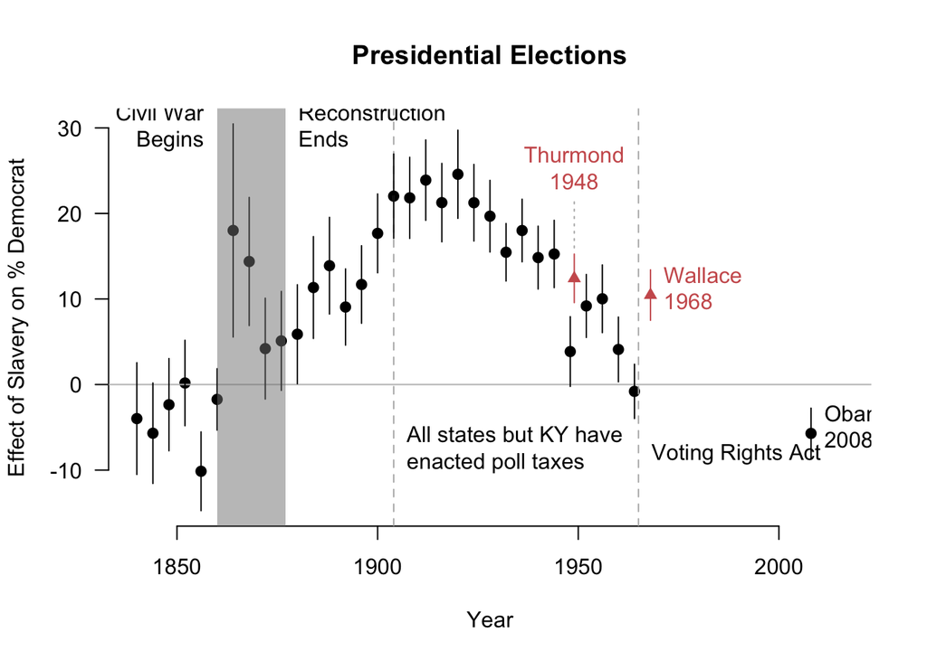

```r
## Most county boundaries are set by 1925 or so.
## variables without the 1860 suffix are based on the 1860 county
## boundaries
pres.form <- formula(. ~ sprop + log(coarea00) + latitude + I(latitude^2) + longitude +
                       I(longitude^2)+ rugged  + land.ineq + sfarmprop + log(totpop) +
                       log(fvalpc) + log(acimp) + fbprop  + rail + water + state.abb)

pres.iv.form <- Formula(. ~ sprop + log(coarea00) + rugged + latitude + I(latitude^2) +
                          longitude + I(longitude^2)  + water  + state.abb | cottonsuit +
                          log(coarea00) + rugged  + latitude + I(latitude^2) + longitude +
                          I(longitude^2) + water  + state.abb)

year.list <- seq(1840, 1964, by = 4)

outvars <- paste("pdem", year.list, sep = "")

pdemcoefs <- matrix(NA, nrow = length(outvars), ncol = 3)

pdemcoefs.nox <- matrix(NA, nrow = length(outvars), ncol = 3)

pdemcoefs.iv <- matrix(NA, nrow = length(outvars), ncol = 3)

pdemcoefs.rfns <- matrix(NA, nrow = length(outvars), ncol = 3)

pdemcoefs.rf <- matrix(NA, nrow = length(outvars), ncol = 3)

#?

for (y in 1:length(outvars)) {
  if (!(outvars[y] %in% c("pdem1864", "pdem1868"))) {
    ## OLS
    ff <- as.formula(paste(outvars[y], " ~ ."))
    if (year.list[y] < 1924) {
      thismod <- lm(update(pres.form, ff), data = countydata, subset = state.abb %in% st.list)
    } else {
      thismod <- lm(update(base1860.form, ff), data = countydata, subset = state.abb %in% st.list)
    }
  }

    pdemcoefs[y,1] <- 0.25*coef(thismod)[2]

    pdemcoefs[y,2:3] <- 0.25*confint(thismod)[2,]

    ## Only state FEs

    if (year.list[y] < 1924) {
      ff <- as.formula(paste(outvars[y], " ~ sprop + state.abb"))
    } else {
      ff <- as.formula(paste(outvars[y], " ~ pslave1860 + state.abb"))
    }

    thismod <- lm(ff, data = countydata, subset = state.abb %in% st.list)

    pdemcoefs.nox[y,1] <- 0.25*coef(thismod)[2]

    pdemcoefs.nox[y,2:3] <- 0.25*confint(thismod)[2,]

    ## IV

    if (year.list[y] < 1924) {
      ff <- update(pres.iv.form, as.formula(paste(outvars[y], "~ . | .")))
    } else {
      ff <- update(base.iv.form, as.formula(paste(outvars[y], "~ . | .")))
    }
    thismod <- ivreg(ff, data = countydata, subset = state.abb %in% st.list)

    pdemcoefs.iv[y,1] <- coef(thismod)[2]

    pdemcoefs.iv[y,2:3] <- confint(thismod)[2,]

    ## Reduced form in the non-south

    ff <- as.formula(paste(outvars[y], "~ cottonsuit + log(coarea00) + rugged+ latitude + I(latitude^2) + longitude + I(longitude^2)   + state.abb"))
    thismod <- lm(ff, data = countydata, subset = !(state.abb %in% st.list) & !(state.abb %in% c("MD", "DE", "MO")))

    pdemcoefs.rfns[y,1] <- coef(thismod)[2]

    pdemcoefs.rfns[y,2:3] <- confint(thismod)[2,]

    ## Reduced form in the south

    thismod <- lm(ff, data = countydata, subset = state.abb %in% st.list)

    pdemcoefs.rf[y,1] <- coef(thismod)[2]

    pdemcoefs.rf[y,2:3] <- confint(thismod)[2,]
  }


# authors make models for the graphics

douglas.ols <- lm(update(pres.form, pdem1860 ~ .), data = countydata, subset = state.abb %in% st.list)
douglas.iv <- ivreg(update(pres.iv.form, pdem1860 ~ .), data = countydata, subset = state.abb %in% st.list)

wallace.ols <- lm(update(base1860.form, wallace68.alt ~ .), data = countydata, subset = state.abb %in% st.list)
wallace.iv <- ivreg(update(base.iv.form, wallace68.alt ~ .), data = countydata, subset = state.abb %in% st.list)
thurmond.ols <- lm(update(base1860.form, thurmond48 ~ .), data = countydata, subset = state.abb %in% st.list)
thurmond.iv <- ivreg(update(base.iv.form, thurmond48 ~ .), data = countydata, subset = state.abb %in% st.list)
obama.ols <- lm(update(base1860.form,  wht.obama.vote ~ .), data = countydata, subset = abs.sample == 1)
obama.iv <- ivreg(update(base.iv.form, wht.obama.vote  ~ .), data = countydata, subset = abs.sample == 1)

# then start plotting for figure 4.

plot(x = year.list, y = 0.25*pdemcoefs.iv[,1],
     ylim = range(c(.25*pdemcoefs.iv,25*confint(obama.iv)["pslave1860",]), na.rm = TRUE),
     xlim=c(min(year.list),2016), xlab = "Year",
     ylab = "Effect of Slavery on % Democrat",
     pch = 19,
     main = "Presidential Elections",
     bty = "n",
     yaxt = "n")

# separate out these calls by year so that it's easier to read

abline(v = 1904, lty = 2, col = "grey70")
text(x = 1904, y = 25*confint(obama.iv)["pslave1860",1]+0.5, "All states but KY have\nenacted poll taxes", pos = 4)


abline(v = 1965, lty = 2, col = "grey70")
text(x = 1965, y =  25*confint(obama.iv)["pslave1860",1]+0.5, "Voting Rights Act", pos = 4)


axis(side = 2, las = 2, cex = 0.8)
abline(h=0, col = "grey")


segments(x0 = year.list, y0 = .25*pdemcoefs.iv[,2], y1 = .25*pdemcoefs.iv[,3])


rect(xleft = 1860, xright = 1877, ybottom = -100, ytop=100, col = rgb(.5,.5,.5, alpha = 0.5), border = NA)
text(x = 1860, y = max(.25*pdemcoefs.iv, na.rm=TRUE)-1, "Civil War\nBegins", pos = 2)


text(x = 1877, y = max(.25*pdemcoefs.iv, na.rm=TRUE)-1, "Reconstruction\nEnds", pos = 4)


points(x = 1968, y = .25*coef(wallace.iv)["pslave1860"], pch = 17, col = "indianred")
segments(x0 = 1968, y0 = 0.25*confint(wallace.iv)["pslave1860",1], y1 = 0.25*confint(wallace.iv)["pslave1860",2], col = "indianred")
text(x = 1968, y = 0.25*coef(wallace.iv)["pslave1860"], "Wallace\n1968", pos = 4, col = "indianred")


points(x = 1949, y = .25*coef(thurmond.iv)["pslave1860"], pch = 17, col = "indianred")
segments(x0 = 1949, y0 = 0.25*confint(thurmond.iv)["pslave1860",1], y1 = 0.25*confint(thurmond.iv)["pslave1860",2], col = "indianred")
text(x = 1949, y = 0.35*confint(thurmond.iv)["pslave1860",2], "Thurmond\n1948", pos = 3, col = "indianred")
segments(x0=1949, y0=0.35*confint(thurmond.iv)["pslave1860",2],y1=0.26*confint(thurmond.iv)["pslave1860",2], lty = 3, col = "grey70")


points(x = 2008, y = 25*coef(obama.iv)["pslave1860"], pch = 19)
segments(x0 = 2008, y0 = 25*confint(obama.iv)["pslave1860",1], y1 = 25*confint(obama.iv)["pslave1860",2])
text(x = 2008, y = 25*coef(obama.iv)["pslave1860"], "Obama\n2008", pos = 4)
```

```r
##dev.off()
```